# Solutions Module 3: Exploratory Data Analysis

Author

Affiliation

Adam Spiegler

University of Colorado Denver

## Additional Reading

- [Chapter 2 Data Cleaning and Exploration](https://jfrench.github.io/LinearRegression/data-cleaning-and-exploration.html) from *A Progressive Introduction to Linear Models*
- [Chapter 3 R for Data Science: Data Transformation](https://r4ds.hadley.nz/data-transform.html)
- Optional: [Chapter 5 R for Data Science: Data Tidying](https://r4ds.hadley.nz/data-tidy.html)

# Loading Required Packages

```r
# load core tidyverse packages
library(tidyverse)
library(janitor)
```

## `tidyverse` Packages

[figure not shown]

The tidyverse logos

The [`tidyverse`](https://www.tidyverse.org/) is a [collection of packages](https://www.tidyverse.org/packages/) by [Hadley Wickham](https://blog.revolutionanalytics.com/2016/09/tidyverse.html) that “share an underlying design philosophy, grammar, and data structures” of tidy data. We can load individual packages within the `tidyverse` one by one, or we can load all packages at once with the command `library(tidyverse)`.

- [`ggplot2`](https://ggplot2.tidyverse.org/): data visualization.
- [`dplyr`](https://dplyr.tidyverse.org/): data wrangling and transformation.
- [`tidyr`](https://tidyr.tidyverse.org/): arrange into tidy data.
- [`readr`](https://readr.tidyverse.org/): importing tables and files from other applications into R.
- [`stringr`](https://stringr.tidyverse.org/): designed to make working with strings easier.
- And others …

# Statistical Inference

A fundamental application of statistics is to use data from a subset of a population to draw conclusions about the population. **Statistical inference** is the process of drawing conclusions about the entire population based on information in a sample.

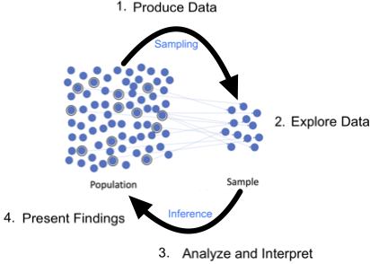

Image Credit: [Loneshieling](https://commons.m.wikimedia.org/wiki/File:Population_versus_sample_%28statistics%29.png), modified by Adam Spiegler, [CC BY-SA 4.0](https://creativecommons.org/licenses/by-sa/4.0).

## Produce Data

**We need data to do statistics!** How we design the collection of data is a crucial first step. If we collect the wrong data or biased data, we cannot gain reasonable insights to achieve our goal even if we do proper analysis. In the end, the conclusions we infer are only as strong as the data we collect.

- Experimental design is an entire field in itself and requires many considerations and techniques to ensure we can reach our ultimate goal.
- Collecting or finding the right data is a critical step that should be carefully planned.
- We do not spend too much time on this aspect of the process this semester, but we should be very aware of how important and delicate this step can be.
- There are many interesting data sets others have already collected that we can easily import into R for further analysis.
- This semester we will mostly be working with data sets that others have already carefully collected rather than produce the data ourselves.

## Explore Data

**Exploratory data analysis**, or **EDA** for short, can be thought of as a cycle:

- Generate questions about our data.
- Search for answers by visualizing, transforming, and modeling our data.
- Use what we learn to refine your questions and/or generate new questions.

The main goal of EDA is to develop an understanding of your data. When we ask a question, the question focuses our attention on a specific part of the data set and helps us decide which graphs, models, or transformations to make.

- EDA can be an intricate process that requires developing some keen investigation skills.
- [Exploratory Data Analysis with R](https://bookdown.org/rdpeng/exdata/) by Roger Peng is a free textbook to help you dig deeper into EDA if interested!
- Our focus this semester will not be on EDA, but at times we will be exploring data in order to uncover our own statistical questions.

## Analyze and Interpret

After we explore data and generate statistical questions to investigate, we apply statistical methods to analyze the data and hopefully gain insight to draw conclusions. Sometimes, even though we carefully perform our analysis correctly, we are unable to reach a decisive conclusion. Sometimes instead of reaching an answer, the insight we gain informs us to refine our question. Other times, it simply leads to more questions! **Probability** is required to do statistical analysis, and we will explore some key results from probability that we will need to apply in this step.

## Present Findings

Finally, after we have interpreted our results, we present our findings to others. Sometimes our colleagues specialize in fields outside of mathematics, statistics, or data science. They rely on us to breakdown our findings in more practical terms accessible to a more general audience.

## Professional Ethics

As we learn and refine our statistical tools, it is our duty to be mindful of the moral and ethical considerations at play in deciding what statistical questions we want to explore, how we produce data, what is the source of our data, what is the benefit to society of our work, and who is impacted by our analysis.

Below is a excerpt from *An Introduction to the Science of Statistics: From Theory to Implementation* by Joseph Watkins that we should always be very mindful of whether we are doing statistical analysis or other endeavors:

> “Those with particular training have a special obligation to bring to the public their special knowledge. Such public statements can take several forms. We can speak out as a member of society with no particular basis in our area of expertise. We can speak out based on the wisdom that comes with this specialized knowledge. Finally, we can speak out based on a formal procedure of gathering information and reporting carefully the results of our analysis. In each case, it is our obligation to be clear about the nature of that communication and that the our statements follow the highest ethical standards. In the same vein, as consumers of information, we should have a clear understanding of the perspective in any document that presents statistical information.”

Below are two sources with ethical guidance to help steer our practice of statistics.

- [*Ethical Guidelines for Statistical Practice*](https://www.amstat.org/your-career/ethical-guidelines-for-statistical-practice) by the American Statistical Association (ASA).
- [*Declaration on Professional Ethics*](https://isi-web.org/declaration-professional-ethics-2010) by the International Statistical Institute.

# Reading Data From An External File

One of the most universal and common file formats for storing files is [**comma-separated file (or CSV file)**](https://en.wikipedia.org/wiki/Comma-separated_values). CSV files:

- Store data in plain text.
- Use commas to separate adjacent cell values.
- Use newlines to separate rows.

## Importing csv Files with `readr::read_csv()`

The `readr` package is a core `tidyverse` package. According to the developers of [`readr`](https://readr.tidyverse.org/index.html):

> The goal of readr is to provide a fast and friendly way to read rectangular data from delimited files, such as comma-separated values (CSV) and tab-separated values (TSV). It is designed to parse many types of data found in the wild, while providing an informative problem report when parsing leads to unexpected results

Compared to the equivalent `base` R functions such as `read.csv()` and `read.table()`, `readr` functions such as `read_csv()` and `read_table()`:

- Are much faster and efficient.
- Bring consistency to importing.
- Produce data frames in a tibble format.
- Have more flexible column specifications.
- Run `?read_csv()` to access help documentation.

## Importing Raw World Bank Regions

The csv file below was [exported from the World Bank] (https://datatopics.worldbank.org/world-development-indicators/the-world-by-income-and-region.html)

> The World Bank classifies economies for analytical purposes into four income groups: low, lower-middle, upper-middle, and high income. For this purpose it uses gross national income (GNI) per capita data in U.S. dollars, converted from local currency using the World Bank Atlas method, which is applied to smooth exchange rate fluctuations.

```r
# creates data frame from csv file
regions_raw <- read_csv("https://raw.githubusercontent.com/aspiegler/Applied-Regression/main/Data/world_bank_regions.csv")
```

```r
class(regions_raw)  # check class of regions_raw
```

```
[1] "spec_tbl_df" "tbl_df"      "tbl"         "data.frame"
```

## Importing csv Files with `base::read.csv()`

The [`read.table()`](https://www.rdocumentation.org/packages/utils/versions/3.6.2/topics/read.table) is a multipurpose function in `base` R for importing data. The more focused functions [`read.csv()`](https://www.geeksforgeeks.org/read-contents-of-a-csv-file-in-r-programming-read-csv-function/) and [`read.delim()`](https://www.geeksforgeeks.org/how-to-use-read-delim-in-r/) have been adjusted (by setting options for the `read_table()` function accordingly) to import more specific file types.

The `base` R function `read.csv()` has very similar syntax as the `readr` function `read_csv()`, namely the first argument (and only required argument) in `read.csv()` is the path to the file.

- Run `?read.csv()` to access help documentation.
- Notice the `tidyverse` function has an underscore `_` and the `base` R function has `.` between `read` and `csv`.

```r
# creates data frame from csv file
regions_df <- read.csv("https://raw.githubusercontent.com/aspiegler/Applied-Regression/main/Data/world_bank_regions.csv")
```

```r
class(regions_df)
```

```
[1] "data.frame"
```

# Useful Summaries of Data Frames

Import a csv file with `read_csv()` or `read.csv()` and store it to an object named `regions_raw`, we will not see what is stored in the object. If we want to see the contents stored in an object on screen, we ask to see something.

## Tibbles

When `tidyverse` packages interact with a data frame, it usually produces a **tibble**.

- Tibbles comes from the [`tibble`](https://tibble.tidyverse.org/) package, which is automatically imported by `readr`.
- A tibble is supposed to be a “modern re-imagining” of R’s standard data frame (referred to as `data.frame` for clarity).
- A tibble has class `tbl_df`.
- A tibble is also a `data.frame`, but has different default behaviors.
- Functions that take a `data.frame` as an input should also take a tibble as an input.

```r
# print tibble regions_raw
regions_raw
```

```
# A tibble: 218 × 5
   Economy             Code  Region            `Income group` `Lending category`
   <chr>               <chr> <chr>             <chr>          <chr>
 1 Afghanistan         AFG   Middle East, Nor… Low income     IDA
 2 Albania             ALB   Europe & Central… Upper middle … IBRD
 3 Algeria             DZA   Middle East, Nor… Upper middle … IBRD
 4 American Samoa      ASM   East Asia & Paci… High income    ??
 5 Andorra             AND   Europe & Central… High income    N/A
 6 Angola              AGO   Sub-Saharan Afri… Lower middle … IBRD
 7 Antigua and Barbuda ATG   Latin America & … High income    IBRD
 8 Argentina           ARG   Latin America & … Upper middle … IBRD
 9 Armenia             ARM   Europe & Central… Upper middle … IBRD
10 Aruba               ABW   Latin America & … High income    missing
# ℹ 208 more rows
```

```r
#print(regions_raw)
```

```r
# print data frame regions_df
regions_df
#print(regions_df)
```

[output not shown]

```r
# additional info displayed for tibbles
str(regions_raw)
```

[output not shown]

```r
# less info displayed for data frames
str(regions_df)
```

[output not shown]

```r
# dplyr glimpse is similar to base::str()
# more streamlined for tibbles than str()
glimpse(regions_raw)
```

[output not shown]

```r
# dplyr glimpse is similar to base::str()
# more or less identical for data frames
glimpse(regions_df)
```

[output not shown]

```r
# gives numeric summary of each variable
# not particularly useful with characters
summary(regions_raw)
```

[output not shown]

```r
# opens preview of data frame in new tab
# not recommended when rendering
View(regions_raw)
```

### Importing a Local File

The **working directory** in R is the default location on your computer where R looks for files to load and where it saves files. It functions as the base path for all relative file operations within an R session or RStudio project. By default, the working directory is typically the same as the directory where the Quarto document is saved.

```r
getwd()
```

```r
# this will import and glimpse
# the data is not assigned to an object
glimpse(read_csv("../Data/world_bank_regions.csv"))
```

**Caution**

When sharing Quarto documents, it is generally not a good practice to include code chunks with `getwd()` or `setwd()` commands since the person you are collaborating with likely has a different file structure and may want to read and write files to/from other locations. Thus, I used the code chunk option `#| eval: false` which means the code cell will be included in the rendered html document, but it will not be executed.

**Caution**

For the similar reasons, using `read_csv()` commands with files stored online (GitHub) is easier to share since the link is the same for everyone no matter the file structure. Using `read_csv()` with a local file may be problematic when sharing, though that is typically not too bad to resolve.

# Cleaning The Data

After importing the data, the next step usually requires transforming it in some way to make it easier for us to perform analysis on the data. What potential issues the data has and how to address them will vary from task to task. Typically, the most common steps include:

1. Renaming variables.
2. Properly coding (and maybe imputing) missing values.
3. Converting categorical variables to `factor` data type.

First we’ll walk through the entire process using only commands from base R. Then we’ll go through a workflow using the `dplyr` package from `tidyverse`. Finally, we’ll demonstrate how to perform all of the steps on import by adding additional arguments to the `read_csv()` function.

## Cleaning Variables Names with `base::names`

Object names:

- Must start with a letter, and
- Can only contain letters, numbers, `_`, and/or `.`.

Object names should be descriptive but brief since each time we refer to the object we do not want to type a lot of characters. When we want to use multiple words to describe an object, we recommend using the `snake_case` method:

- Use lowercase letters.
- Separate words with the underscore character, `_`.
- If needed, abbreviate longer words.

```r
regions_renamed <- regions_raw  # store result to new data frame rather than overwrite
names(regions_renamed) <- c("country", "country_code", "region", "income_group", "lending_cat")
glimpse(regions_renamed)
```

```
Rows: 218
Columns: 5
$ country      <chr> "Afghanistan", "Albania", "Algeria", "American Samoa", "A…
$ country_code <chr> "AFG", "ALB", "DZA", "ASM", "AND", "AGO", "ATG", "ARG", "…
$ region       <chr> "Middle East, North Africa, Afghanistan & Pakistan", "Eur…
$ income_group <chr> "Low income", "Upper middle income", "Upper middle income…
$ lending_cat  <chr> "IDA", "IBRD", "IBRD", "??", "N/A", "IBRD", "IBRD", "IBRD…
```

## Cleaning Missing Data

One of the most common transformations is converting non-standard ways of coding missing values into proper `NA` values in R.

A **missing value** occurs when the value of something isn’t known. R uses the special object `NA` to represent missing values. If you have a missing value, you should represent that value as `NA`. Note: The character string `"NA"` is not the same thing as `NA`.

- Do not make the mistake of using `-99`, `0`,`" "`, `"NA"`, or anything other than `NA` to indicate a missing value.
- It is common for somebody to share data with you that has missing values coded improperly.

From the output of the previous code cell, some missing `lending_cat` values have been properly coded as `NA`. Others have been improperly coded as `"??"`, `"N/A"`, and `"missing"`. The other variables do not have any missing values.

- The logical statement `regions_fix_na$lending_cat == "??"` extracts just the observations with `lending_cat` equal to `"??"`.
- Then we assign the value `NA` as the new value for `lending_cat` for these observations.

```r
regions_na <- regions_renamed  # store result to new data frame rather than overwrite
regions_na$lending_cat[regions_na$lending_cat == "??"] <- NA
glimpse(regions_na)
```

```
Rows: 218
Columns: 5
$ country      <chr> "Afghanistan", "Albania", "Algeria", "American Samoa", "A…
$ country_code <chr> "AFG", "ALB", "DZA", "ASM", "AND", "AGO", "ATG", "ARG", "…
$ region       <chr> "Middle East, North Africa, Afghanistan & Pakistan", "Eur…
$ income_group <chr> "Low income", "Upper middle income", "Upper middle income…
$ lending_cat  <chr> "IDA", "IBRD", "IBRD", NA, "N/A", "IBRD", "IBRD", "IBRD",…
```

```r
regions_na$lending_cat[regions_na$lending_cat == "N/A"] <- NA
regions_na$lending_cat[regions_na$lending_cat == "missing"] <- NA
glimpse(regions_na)
```

```
Rows: 218
Columns: 5
$ country      <chr> "Afghanistan", "Albania", "Algeria", "American Samoa", "A…
$ country_code <chr> "AFG", "ALB", "DZA", "ASM", "AND", "AGO", "ATG", "ARG", "…
$ region       <chr> "Middle East, North Africa, Afghanistan & Pakistan", "Eur…
$ income_group <chr> "Low income", "Upper middle income", "Upper middle income…
$ lending_cat  <chr> "IDA", "IBRD", "IBRD", NA, NA, "IBRD", "IBRD", "IBRD", "I…
```